# Chapter 3) Logistic regrsession

```r
date()
```

```
## [1] "Fri Nov 18 11:57:46 2022"
```

## Reading data

The data consists of student performance data in two Portuguese schools, collected by reports and questionnaires. It consists of two datasets from two different subjects: math and Portuguese. These datasets were combined and the variables of the combined dataset are printed below. In addition, two variables were calculated: *alc_use* is the average alcohol use from weekdays and weekends and *high_use* tells is true when *alc_use* is over *2*

More information (including variable information) and the original dataset can be found from [UCI_machine_learning_repository](https://archive.ics.uci.edu/ml/datasets/Student+Performance)

```r
alc <- read.csv("C:/Users/labpaavo/IODS-project/data/alc.csv")

colnames(alc)
```

```
##  [1] "school"     "sex"        "age"        "address"    "famsize"
##  [6] "Pstatus"    "Medu"       "Fedu"       "Mjob"       "Fjob"
## [11] "reason"     "guardian"   "traveltime" "studytime"  "schoolsup"
## [16] "famsup"     "activities" "nursery"    "higher"     "internet"
## [21] "romantic"   "famrel"     "freetime"   "goout"      "Dalc"
## [26] "Walc"       "health"     "failures"   "paid"       "absences"
## [31] "G1"         "G2"         "G3"         "alc_use"    "high_use"
```

## Variables of interest in relation to alcohol consumption and hypotheses

For the variables of interest in relation to high/low alcohol consumption I have chosen: sex, Pstatus, studytime and absences. The hypotheses are that:  
- being a male predicts high alcohol consumption  
- parents living apart predicts high alcohol consumption  
- low studytime predicts high alcohol consumption  
- high absences predicts high alcohol consumption

## Exploring the chosen variables

Numerically and graphically explore the distributions of your chosen variables and their relationships with alcohol consumption (use for example cross-tabulations, bar plots and box plots). Comment on your findings and compare the results of your exploration to your previously stated hypotheses. (0-5 points)

```r
library(descr)
library(dplyr)
```

```r
library(ggplot2)

my_variables = c("high_use", "sex", "Pstatus", "studytime", "absences")
my_data <- alc[my_variables]

summary(my_data)
```

```
##   high_use           sex              Pstatus            studytime
##  Mode :logical   Length:370         Length:370         Min.   :1.000
##  FALSE:259       Class :character   Class :character   1st Qu.:1.000
##  TRUE :111       Mode  :character   Mode  :character   Median :2.000
##                                                        Mean   :2.043
##                                                        3rd Qu.:2.000
##                                                        Max.   :4.000
##     absences
##  Min.   : 0.000
##  1st Qu.: 1.000
##  Median : 3.000
##  Mean   : 4.511
##  3rd Qu.: 6.000
##  Max.   :45.000
```

```r
CrossTable(my_data$high_use, my_data$sex)
```

```
##    Cell Contents
## |-------------------------|
## |                       N |
## | Chi-square contribution |
## |           N / Row Total |
## |           N / Col Total |
## |         N / Table Total |
## |-------------------------|
##
## =========================================
##                     my_data$sex
## my_data$high_use        F       M   Total
## -----------------------------------------
## FALSE                 154     105     259
##                     2.244   2.500
##                     0.595   0.405   0.700
##                      0.79    0.60
##                     0.416   0.284
## -----------------------------------------
## TRUE                   41      70     111
##                     5.235   5.833
##                     0.369   0.631   0.300
##                      0.21    0.40
##                     0.111   0.189
## -----------------------------------------
## Total                 195     175     370
##                     0.527   0.473
## =========================================
```

```r
CrossTable(my_data$high_use, my_data$Pstatus)
```

```
##    Cell Contents
## |-------------------------|
## |                       N |
## | Chi-square contribution |
## |           N / Row Total |
## |           N / Col Total |
## |         N / Table Total |
## |-------------------------|
##
## =========================================
##                     my_data$Pstatus
## my_data$high_use        A       T   Total
## -----------------------------------------
## FALSE                  26     233     259
##                     0.014   0.002
##                     0.100   0.900   0.700
##                     0.684   0.702
##                     0.070   0.630
## -----------------------------------------
## TRUE                   12      99     111
##                     0.032   0.004
##                     0.108   0.892   0.300
##                     0.316   0.298
##                     0.032   0.268
## -----------------------------------------
## Total                  38     332     370
##                     0.103   0.897
## =========================================
```

```r
CrossTable(my_data$high_use, my_data$studytime)
```

```
##    Cell Contents
## |-------------------------|
## |                       N |
## | Chi-square contribution |
## |           N / Row Total |
## |           N / Col Total |
## |         N / Table Total |
## |-------------------------|
##
## =========================================================
##                     my_data$studytime
## my_data$high_use        1       2       3       4   Total
## ---------------------------------------------------------
## FALSE                  56     128      52      23     259
##                     2.314   0.017   2.381   0.889
##                     0.216   0.494   0.201   0.089   0.700
##                     0.571   0.692   0.867   0.852
##                     0.151   0.346   0.141   0.062
## ---------------------------------------------------------
## TRUE                   42      57       8       4     111
##                     5.400   0.041   5.556   2.075
##                     0.378   0.514   0.072   0.036   0.300
##                     0.429   0.308   0.133   0.148
##                     0.114   0.154   0.022   0.011
## ---------------------------------------------------------
## Total                  98     185      60      27     370
##                     0.265   0.500   0.162   0.073
## =========================================================
```

```r
my_data %>% group_by(high_use) %>% summarise(count = n(), mean_absences = mean(absences))
```

```
## # A tibble: 2 × 3
##   high_use count mean_absences
##   <lgl>    <int>         <dbl>
## 1 FALSE      259          3.71
## 2 TRUE       111          6.38
```

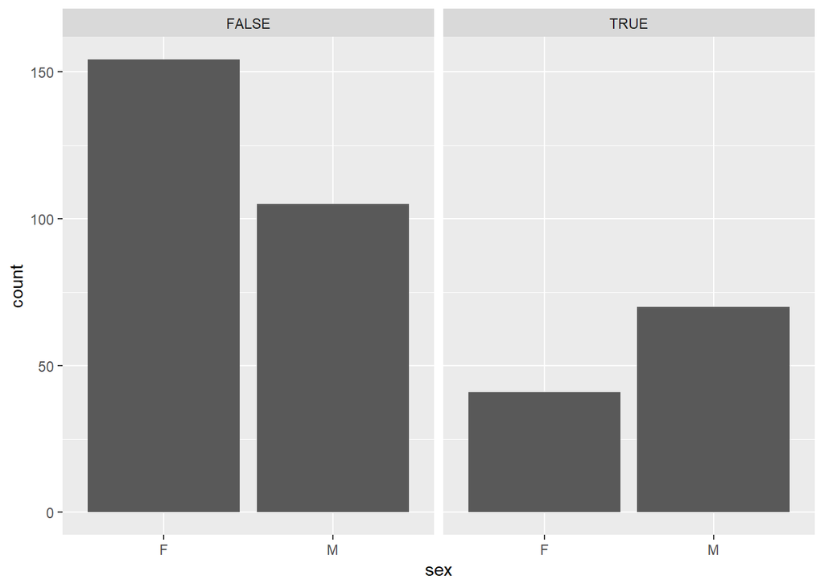

```r
g1 <-  ggplot(data = my_data, aes(x = sex))
g1 + geom_bar() + facet_wrap("high_use")
```

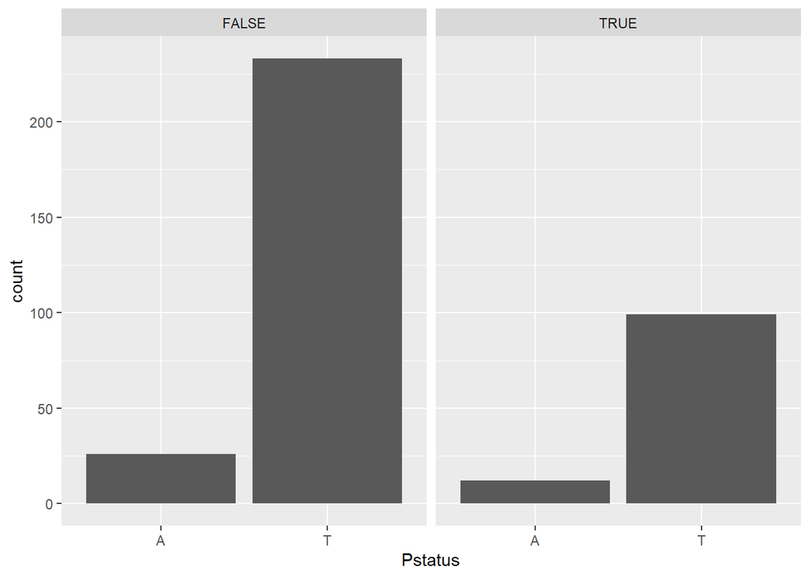

```r
g2 <-  ggplot(data = my_data, aes(x = Pstatus))
g2 + geom_bar() + facet_wrap("high_use")
```

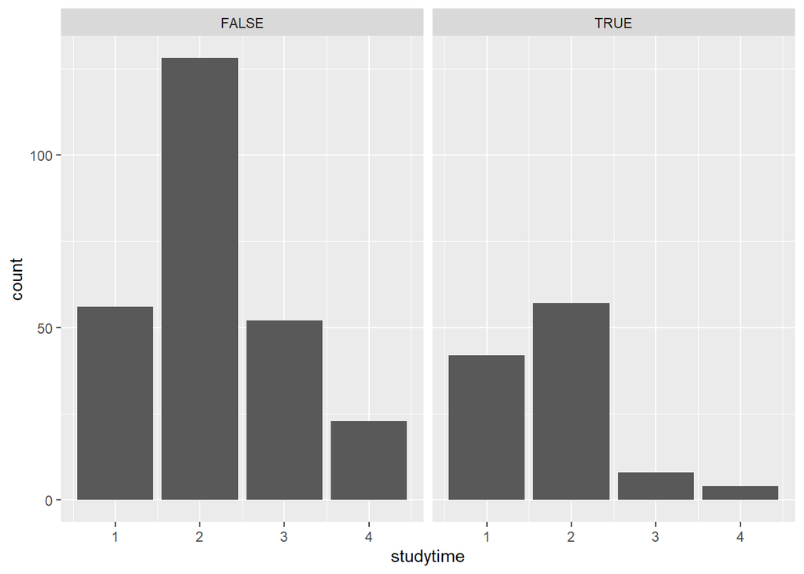

```r
g3 <-  ggplot(data = my_data, aes(x = studytime))
g3 + geom_bar() + facet_wrap("high_use")
```

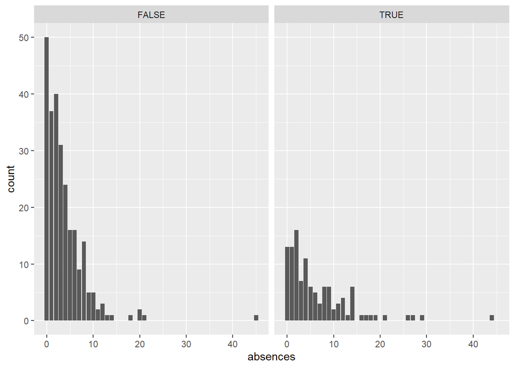

```r
g4 <-  ggplot(data = my_data, aes(x = absences))
g4 + geom_bar() + facet_wrap("high_use")
```

## Logistic regression

```r
m <- glm(high_use ~ sex + Pstatus + studytime + absences, data = my_data, family = "binomial")
summary(m)
```

```
##
## Call:
## glm(formula = high_use ~ sex + Pstatus + studytime + absences,
##     family = "binomial", data = my_data)
##
## Deviance Residuals:
##     Min       1Q   Median       3Q      Max
## -2.1339  -0.8389  -0.5966   1.0728   2.1221
##
## Coefficients:
##             Estimate Std. Error z value Pr(>|z|)
## (Intercept) -1.01835    0.55916  -1.821 0.068574 .
## sexM         0.84663    0.25509   3.319 0.000903 ***
## PstatusT     0.12379    0.40420   0.306 0.759415
## studytime   -0.41526    0.16023  -2.592 0.009550 **
## absences     0.08928    0.02345   3.807 0.000141 ***
## ---
## Signif. codes:  0 '***' 0.001 '**' 0.01 '*' 0.05 '.' 0.1 ' ' 1
##
## (Dispersion parameter for binomial family taken to be 1)
##
##     Null deviance: 452.04  on 369  degrees of freedom
## Residual deviance: 408.40  on 365  degrees of freedom
## AIC: 418.4
##
## Number of Fisher Scoring iterations: 4
```

```r
OR <- coef(m) %>% exp
CI <- confint(m) %>% exp
cbind(OR, CI)
```

```
##                    OR     2.5 %    97.5 %
## (Intercept) 0.3611909 0.1172496 1.0606103
## sexM        2.3317700 1.4202152 3.8687722
## PstatusT    1.1317735 0.5251790 2.5945605
## studytime   0.6601657 0.4776116 0.8967295
## absences    1.0933826 1.0465506 1.1475274
```

Logistic regression models showed that sex, studytime and absences were significant predictors high/low alcohol consumptions:  
sexM log odds .85 (p-value <0.001) studytime log odds -.42 (p-value < 0.01), meaning that for unit increase in studytime the log odds for being n high alcohol consumption decrease by 0.42.  
absences log odds .09 (p-value <0.001), meaning that for each absence the log odds for high alcohol consumption changes by 0.09.

The odds for a male being in high alcohol consumption groups over a female is 2.3 (CI 1.4; 3.9). For unit increase in studytime the odds of being in high alcohol consumption group decrese by 34% (CI 0.48; 0.90), note that studytime had four possible values corresponging to <2 hours, 2 to 5 hours, 5 to 10 hours and >10 hours. For each absence the odds of being in high alcohol consumption group increase by 9.3% (CI 4.7%; 14.8%).

Against the initial hypothesis parental status did not predict alcohol consumption, however this was could be predicted already by exploring the data. The effect of sex, studytime and absences were as hypothesized as being a male, lower studytime and higher absences predicted being in high alcohol consumption group.

## Predictive power of the model

```r
# drop parental status from the model as it wasn't statistically significant predictor
new_model <- glm(high_use ~ sex + studytime + absences, data = my_data, family = "binomial")

probabilities <- predict(new_model, type = "response")
my_data <- mutate(my_data, probability = probabilities)
my_data <- mutate(my_data, prediction = (probability > 0.5))

table(high_use = my_data$high_use, prediction = my_data$prediction)
```

```
##         prediction
## high_use FALSE TRUE
##    FALSE   250    9
##    TRUE     86   25
```

```r
loss_func <- function(class, prob) {
  n_wrong <- abs(class - prob) > 0.5
  mean(n_wrong)
}

# training error
loss_func(class = my_data$high_use, prob = my_data$probability)
```

```
## [1] 0.2567568
```

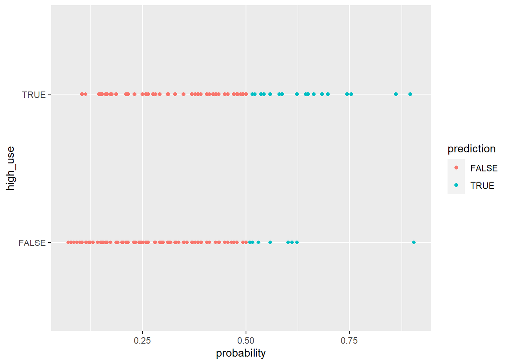

```r
g <- ggplot(my_data, aes(x = probability, y = high_use, col = prediction))
g + geom_point()
```

The model resulted in 250 true negatives, 25 true positives, 86 false negatives and 9 false positives.  
The training error of the model is 25.7%.

## 10-fold cross-validation

```r
loss_func <- function(class, prob) {
  n_wrong <- abs(class - prob) > 0.5
  mean(n_wrong)
}

# compute the average number of wrong predictions in the (training) data
loss_func(class = my_data$high_use, prob = my_data$probability)
```

```
## [1] 0.2567568
```

```r
# K-fold cross-validation
library(boot)
cv <- cv.glm(data = alc, cost = loss_func, glmfit = m, K = 10)

# average number of wrong predictions in the cross validation
cv$delta[1]
```

```
## [1] 0.2594595
```